# Analysis of a genome annotation table

Probabilités et statistique pour la biologie (STAT1)

Jacques van Helden

2019-09-19

## Goal of this practical

During this practical session, you will run the following tasks:

1. Handle a table containing annotated features of the yeast genome.
2. Select a subset of the data by filtering rows based on a given criterion (annotation type, chromosome, …)
3. Generate graphics to represent different aspects of the data.
4. Compute estimators of central tendency and dispersion.
5. Compute a confidence interval around the mean.

## Expected report

At the end of the practical you will be asked to submit two documents

1. Your **R code**.Each question must be explicitly formulated before presenting the results that answer it and giving an interpretation of these results.
2. UA **synthetic report**, which will include a presentation of the main results (figures, descriptives stats, tables) as well as your interpretation of the result.

### Expectation for the code

1. The code must be **readable and undestandable**: choose variable names that explicitly indicate what they represent.
2. The code must be properly documented (the `#` symbol starts a comment, either at the begining or in the middle of a line of code).
   - Before each chunk of code, explain what this code is supposed to do, what it serves to.
   - Don’t hesitate to occasionally add some comment words to justify the chosen approach.
   - Each time you define a variable, add a comment on the same line to indicate what this variable represents.
3. The code must be **portable**: other people should be able to download it and run it on their computer. For this practical, I will systematically test whether your code can run on my computer. hard-coded absolute paths of a file on your machine should thus always be avoided (we will indicate hereafter how to define relative paths relative to the root of your user account).

### Expected content for the interpretation report

Your report must be synthetic (1 text page max + as many figures and table as you wish) Le rapport doit être synthétique (1 page de texte maximum + autant de figures et tables que vous le désirez).

Each question must be explicitly formulated before presenting the results that answer it and then interpreting those results.  
Chaque question doit être exprimée explicitement avant de présenter les résultats qui y répondent et de fournir l’interprétation de ces résultats.

Each figure or table must be documented with a legend that allows a naive reader to understand what it represents. The interpretation of the results displayed on a figure or table will be found in the main text (with a reference to the figure or table number). Chaque figure ou table doit être documentée par une légende permettant à un lecteur naïf de comprendre ce qu’elle représente. L’interprétation des résultats affichés sur une figure ou table se trouvera dans le texte principal (avec une référence au numéro de figure ou table).

## Historical example: yeast genome

- 1992: publication of the first complete eukaryotic chromosome, the 3rd yeast chromosome.
- 1996: publication of the complete genome.

On the base of the genes of the 3rd chromosome (sample) we can estimate the average size of a yeast gene.

**Questions:**

1. Would the sample mean (chromosome III) be sufficient to predict the population mean (complete genome) ?

   To answer this question, we will imagine that we came back in 1992, and will use all the genes of chromosome III (considered here as a sample of the genome) to estimate the average size of genes for the whole genome (the “population” of genes“).
2. Can this sample be described as “simple and independent” ?

## Analysis of the length of the baker’s yeast genes

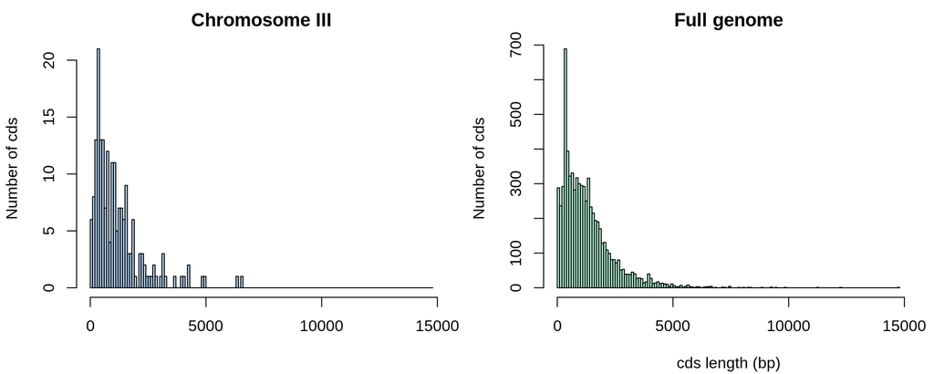

Distribution of cds lengths for Saccharomyces cerevisiae.

## Tutorial

Before moving to the exercises, we show you here some basic elements about reading, manipulating and writing data tables with R.

### The path to the home (manual)

We will create a folder for this tutorial, starting from the root of our account.

First possibility (**quick but not very elegant**): enter (manually) the path from the root of your account in a variable

`dir.home <- /the/path/to/the/home`

- Advantage: fast and convenient
- Disadvantage: not portable, will only work on your computer

### The path to the home (automatic)

A more general solution: use the **R** command `Sys.getenv()`.

- Invoked without parameters, this command lists all environment variables (your system configuration).
- The output can be restricted to a given environment variable, for example `Sys.getenv("HOME")` returns the path to the root of your account.

**Note:** equivalent writing with Linux: the tilde symbol `~` also indicates the path to the root of your account.

```r
## Identify the home directory
## by getting the environment variable HOME
dir.home <- Sys.getenv("HOME")
print(dir.home)
```

```
[1] "/home/khamvongsa"
```

### Creating a folder for the TP

```r
## Define a variable containing the path of the results for this tutorial
dir.tuto <- file.path(dir.home, "stat1", "TP2")

print(dir.tuto)
```

```
[1] "/home/khamvongsa/stat1/TP2"
```

```r
## Create the directory for this tutorial
dir.create(path = dir.tuto, showWarnings = FALSE, recursive = TRUE)

## Go to the tutorial directory
setwd(dir.tuto)

## List the files already present in the folder (if any)
list.files()
```

```
[1] "3nt_genomic_Saccharomyces_cerevisiae-ovlp-1str.tab"
[2] "chrom_sizes.tsv"
[3] "Saccharomyces_cerevisiae.R64-1-1.37.gtf.gz"
```

### Downloading the GTF file from EnsemblGenomes

**Tips:** before downloading the annotation file (GTF) from EnsemblGenomes to our computer, we will check if it is already present (and in this case we do not re-download it).

```r
## Define the URL of the annotation file (GTF-formatted)
gtf.URL <- "ftp://ftp.ensemblgenomes.org/pub/release-37/fungi/gtf/saccharomyces_cerevisiae/Saccharomyces_cerevisiae.R64-1-1.37.gtf.gz"

## Define the path where the local copy will be stored
local.GTF <- file.path(dir.tuto, "Saccharomyces_cerevisiae.R64-1-1.37.gtf.gz")

## If the local file file laready exists, skip the download
if (file.exists(local.GTF)) {
  message("GTF file already exists in the tutorial folder: ", local.GTF)
} else {
  ## Download annotation table in GTF format
  download.file(url = gtf.URL, destfile = local.GTF)
}
```

### Loading a data table

R has several types of tabular structures (matrix, data.frame, table).

The most commonly used structure is the `data.frame`, which consists of an array of values (numeric or strings) whose rows and columns are associated with names.

The function `read.table()` allows you to read a text file containing a data table, and store the content in a variable.

Several functions derived from `read.table()` make it easier to read different types of formats:

- `read.delim()` for files whose columns are delimited by a particular character (usually the tab, represented by “”).
- `read.csv()` for files “comma-searated values”.
1. Download the following file to your computer:
- Saccharomyces_cerevisiae.R64-1-1.37.gtf
2. Load it using the read.table function (for this you must replace the path below by that of your computer).

```r
## Read a GTF file with yeast genome annotations

## Load the feature table
feature.table <- read.table(
  local.GTF,
  comment.char = "#",
  sep="\t",
  header=FALSE,
  row.names=NULL)

## The bed format does not contain any column header,
## so we set it manually based on the description of the format,
## found here:
##     http://www.ensembl.org/info/website/upload/gff.html
names(feature.table) <- c("seqname", "source", "feature", "start", "end", "score", "strand", "frame", "attribute")
```

### Exploring the content of a data table

The first thing to do after loading a data table is to check its dimensions.

```r
dim(feature.table) ## Dimensions of the tbale
```

```
[1] 43028     9
```

```r
nrow(feature.table) ## Number of rows
```

```
[1] 43028
```

```r
ncol(feature.table) ## Number of columns
```

```
[1] 9
```

The display of the complete annotation table would not be very readable, since it contains tens of thousands of lines.

We can display the first lines with the function `head()`.

**Note:** the last column is particularly heavy (it contains a lot of information). We will see later how to select a subset of the columns to simplify the display.

```r
## Display the 5 first rows of the feature table
head(feature.table, n = 5)
```

```
  seqname source     feature start  end score strand frame
1      IV    SGD        gene  1802 2953     .      +     .
2      IV    SGD  transcript  1802 2953     .      +     .
3      IV    SGD        exon  1802 2953     .      +     .
4      IV    SGD         CDS  1802 2950     .      +     0
5      IV    SGD start_codon  1802 1804     .      +     0
                                                                                                                                                                                                                                    attribute
1                                                                                                                                                              gene_id YDL248W; gene_name COS7; gene_source SGD; gene_biotype protein_coding;
2                                                       gene_id YDL248W; transcript_id YDL248W; gene_name COS7; gene_source SGD; gene_biotype protein_coding; transcript_name COS7; transcript_source SGD; transcript_biotype protein_coding;
3                     gene_id YDL248W; transcript_id YDL248W; exon_number 1; gene_name COS7; gene_source SGD; gene_biotype protein_coding; transcript_name COS7; transcript_source SGD; transcript_biotype protein_coding; exon_id YDL248W.1;
4 gene_id YDL248W; transcript_id YDL248W; exon_number 1; gene_name COS7; gene_source SGD; gene_biotype protein_coding; transcript_name COS7; transcript_source SGD; transcript_biotype protein_coding; protein_id YDL248W; protein_version 1;
5                                        gene_id YDL248W; transcript_id YDL248W; exon_number 1; gene_name COS7; gene_source SGD; gene_biotype protein_coding; transcript_name COS7; transcript_source SGD; transcript_biotype protein_coding;
```

The function `tail()` displays the last few lines:

```r
## Display the 5 last rows of the feature table
tail(feature.table, n = 5)
```

```
      seqname source     feature start   end score strand frame
43024    Mito    SGD  transcript 85554 85709     .      +     .
43025    Mito    SGD        exon 85554 85709     .      +     .
43026    Mito    SGD         CDS 85554 85706     .      +     0
43027    Mito    SGD start_codon 85554 85556     .      +     0
43028    Mito    SGD  stop_codon 85707 85709     .      +     0
                                                                                                                                                                                            attribute
43024                                                     gene_id Q0297; transcript_id Q0297; gene_source SGD; gene_biotype protein_coding; transcript_source SGD; transcript_biotype protein_coding;
43025                     gene_id Q0297; transcript_id Q0297; exon_number 1; gene_source SGD; gene_biotype protein_coding; transcript_source SGD; transcript_biotype protein_coding; exon_id Q0297.1;
43026 gene_id Q0297; transcript_id Q0297; exon_number 1; gene_source SGD; gene_biotype protein_coding; transcript_source SGD; transcript_biotype protein_coding; protein_id Q0297; protein_version 1;
43027                                      gene_id Q0297; transcript_id Q0297; exon_number 1; gene_source SGD; gene_biotype protein_coding; transcript_source SGD; transcript_biotype protein_coding;
43028                                      gene_id Q0297; transcript_id Q0297; exon_number 1; gene_source SGD; gene_biotype protein_coding; transcript_source SGD; transcript_biotype protein_coding;
```

If you are using the **RStudio** environment, you can display the table in a dynamic viewer pane with the function `View()`.

```r
## In RStudio, display the table in a separate tab
View(feature.table)
```

### Selection of subsets from a table

Selection of a line specified by its index.

```r
feature.table[12,]
```

```
   seqname source    feature start  end score strand frame
12      IV    SGD stop_codon  3834 3836     .      +     0
                                                                                                                                                            attribute
12 gene_id YDL247W-A; transcript_id YDL247W-A; exon_number 1; gene_source SGD; gene_biotype protein_coding; transcript_source SGD; transcript_biotype protein_coding;
```

Selection of a column specified by its index (display of the first values only).

```r
head(feature.table[,3])
```

```
[1] gene        transcript  exon        CDS         start_codon stop_codon
Levels: CDS exon gene start_codon stop_codon transcript
```

Selection of a cell by combining row and column indices.

```r
feature.table[12, 3]
```

```
[1] stop_codon
Levels: CDS exon gene start_codon stop_codon transcript
```

Selection of a column and/or row set.

```r
feature.table[100:105, 1:6]
```

```
    seqname source     feature start   end score
100      IV    SGD         CDS 34240 36477     .
101      IV    SGD start_codon 36475 36477     .
102      IV    SGD  stop_codon 34237 34239     .
103      IV    SGD        gene 36797 38173     .
104      IV    SGD  transcript 36797 38173     .
105      IV    SGD        exon 36797 38173     .
```

Selection of specific columns (here, the genomic coordinates of each feature): chromosome, beginning, end, strand.

```r
feature.table[100:105, c(1,4,5,7)]
```

```
    seqname start   end strand
100      IV 34240 36477      -
101      IV 36475 36477      -
102      IV 34237 34239      -
103      IV 36797 38173      +
104      IV 36797 38173      +
105      IV 36797 38173      +
```

Select a column based on its name.

```r
## Select the "start" column and print the 100 first results
head(feature.table$start, n=100)
```

```
  [1]  1802  1802  1802  1802  1802  2951  3762  3762  3762  3762  3762
 [12]  3834  5985  5985  5985  5985  5985  7812  8683  8683  8683  8686
 [23]  9754  8683 11657 11657 11657 11660 13358 11657 16204 16204 16204
 [34] 16204 16204 17224 17577 17577 17577 17580 18564 17577 18959 18959
 [45] 18959 18959 18959 19310 20635 20635 20635 20635 20635 21004 22471
 [56] 22471 22471 22474 22606 22471 22823 22823 22823 22823 22823 25874
 [67] 26403 26403 26403 26406 28773 26403 28985 28985 28985 28988 30452
 [78] 28985 30657 30657 30657 30657 30657 31827 32296 32296 32296 32296
 [89] 32296 33232 33415 33415 33415 33418 33916 33415 34237 34237 34237
[100] 34240
```

```r
## Print the 20 first values of the "feature" field, which indicates the feature type
head(feature.table$feature, n=20)
```

```
 [1] gene        transcript  exon        CDS         start_codon
 [6] stop_codon  gene        transcript  exon        CDS
[11] start_codon stop_codon  gene        transcript  exon
[16] CDS         start_codon stop_codon  gene        transcript
Levels: CDS exon gene start_codon stop_codon transcript
```

Selection of several columns based on their names.

```r
## Select the "start" column and print the 100 first results
feature.table[100:106, c("seqname", "start", "end", "strand")]
```

```
    seqname start   end strand
100      IV 34240 36477      -
101      IV 36475 36477      -
102      IV 34237 34239      -
103      IV 36797 38173      +
104      IV 36797 38173      +
105      IV 36797 38173      +
106      IV 36797 38170      +
```

**Note**: Selection of several columns based on their names. It is also possible to name the rows of a data.frame but the GTF table does not support this. We will see more examples later.

### Selection of a subset of rows based on the content of a column

The function `subset()` allows you to select a subset of the rows of a data.frame based on a condition applied to one or more columns.

We can apply it to select the subset of rows in the annotation table corresponding to coding sequences (CDS).

```r
## Select subset of features having "cds" as "feature" attribute
cds <- subset(feature.table, feature=="cds")

nrow(feature.table) ## Count the number of features
```

```
[1] 43028
```

```r
nrow(cds) ## Count the number of cds
```

```
[1] 0
```

### Count by value

The function `table()` allows you to count the occurrences of each value in a vector or array. Some examples of use below.

```r
## Count the number of featues per chromosome
table(feature.table$seqname)
```

```
   I   II  III   IV   IX Mito    V   VI  VII VIII    X   XI  XII XIII  XIV
 759 2912 1210 5374 1567  327 2159  946 3856 2054 2617 2231 3789 3311 2774
  XV  XVI
3846 3296
```

```r
## Count the number of features per type
table(feature.table$feature)
```

```
        CDS        exon        gene start_codon  stop_codon  transcript
       7050        7872        7445        6700        6516        7445
```

Contingency tables can be calculated by counting the number of combinations between 2 vectors (or 2 columns of a table).

```r
##  Table with two vectors
table(feature.table$feature, feature.table$seqname)
```

```
                I  II III  IV  IX Mito   V  VI VII VIII   X  XI XII XIII
  CDS         122 492 194 895 255   59 345 151 619  346 422 361 615  544
  exon        137 525 224 961 288   94 400 180 710  373 480 404 698  610
  gene        132 494 213 914 274   62 383 167 676  349 458 388 658  573
  start_codon 119 464 185 853 243   28 328 143 593  325 406 348 586  514
  stop_codon  117 443 181 837 233   22 320 138 582  312 393 342 574  497
  transcript  132 494 213 914 274   62 383 167 676  349 458 388 658  573

              XIV  XV XVI
  CDS         458 623 549
  exon        500 689 599
  gene        475 665 564
  start_codon 438 607 520
  stop_codon  428 597 500
  transcript  475 665 564
```

```r
## Same result with a 2-column data frame
table(feature.table[, c("feature", "seqname")])
```

```
             seqname
feature         I  II III  IV  IX Mito   V  VI VII VIII   X  XI XII XIII
  CDS         122 492 194 895 255   59 345 151 619  346 422 361 615  544
  exon        137 525 224 961 288   94 400 180 710  373 480 404 698  610
  gene        132 494 213 914 274   62 383 167 676  349 458 388 658  573
  start_codon 119 464 185 853 243   28 328 143 593  325 406 348 586  514
  stop_codon  117 443 181 837 233   22 320 138 582  312 393 342 574  497
  transcript  132 494 213 914 274   62 383 167 676  349 458 388 658  573
             seqname
feature       XIV  XV XVI
  CDS         458 623 549
  exon        500 689 599
  gene        475 665 564
  start_codon 438 607 520
  stop_codon  428 597 500
  transcript  475 665 564
```

## Exercises

### 1. GTF format specifications

Read the GTF format specifications.

- Ensembl (http://www.ensembl.org/info/website/upload/gff.html)
- UCSC (https://genome.ucsc.edu/FAQ/FAQformat.html#format4)

### 2. Creating a local folder for the TP

Create a local folder (for example: `stat1/TP_yeast` from the root of your account). We suggest you to use the following functions:

- `Sys.getenv("HOME")` (Linnux and Mac OS X), to get the root of your user account;
- `file.path()` to build a path;
- `dir.create()` to create the folder for the TP. Read carefully the options of this function with `help(dir.create)`

### 3. Locating the annotation file

Locate the yeast genome annotation file in GTF format in this local folder.

- Site Ensembl Fungi: http://fungi.ensembl.org/
- Click “Downloads” to access the [ftp website](http://fungi.ensembl.org/info/website/ftp/)
- In the search box, type *“saccharomyces cerevisiae”* and follow the link “GTF”
- Copy the address (URL) of the file Saccharomyces_cerevisiae.R64-1-1.37.gtf.gz

### 4. Downloading a file from an ftp site

Suggested functions:

- `download.file()` (read the help to know the arguments)

### 5. Loading a data table in R

Write a script that loads the data table into a variable named `feature.table`, using the function R `read.delim()`.

Be sure to ignore the comment lines (which start with a character `#`).

### 6. Compute the length of coding genes

- Add to the annotation table (`feature.table`) a column entitled “length” which indicates the length of each annotated genomic feature.

```r
## Add a colmn with feature lengths
feature.table[, "length"] <- feature.table[, "end"] - feature.table[, "start"] + 1

## Add a colmn with feature lengths: equivalent result with simpler notation
feature.table$length <- feature.table$end - feature.table$start + 1
```

- Count the number of rows in the table corresponding to each type of annotation (3rd column of the GTF, “feature”).
  - fonction `table()`

```r
~table(feature.table$feature)
```

```
~table(feature.table$feature)
```

- Select the lines corresponding to coding regions (“CDS”)
  - fonction `subset()`

```r
cds <- subset(feature.table, feature=="CDS")
```

- Count the number of CDS per chromosome.
  - fonction `table()`

```r
table(cds$seqname)
```

```
   I   II  III   IV   IX Mito    V   VI  VII VIII    X   XI  XII XIII  XIV
 122  492  194  895  255   59  345  151  619  346  422  361  615  544  458
  XV  XVI
 623  549
```

- Load the chromosome size table chrom_sizes.tsv, and calculate the gene density for each chromosome (number of genes per Mb).

```r
## Download tab-delimited file with chromosome sizes (unless already there)
annot.url <- "http://jvanheld.github.io/stat1/data/Saccharomyces_cerevisiae/chrom_sizes.tsv"
chrom.size.file <- file.path(dir.tuto, "chrom_sizes.tsv")

if (!file.exists(chrom.size.file)) {
    download.file(annot.url, destfile = chrom.size.file)
}

## Read chromosome sizes
chrom.size <- read.delim(
  file = chrom.size.file,
  header = FALSE, row.names = 1)

## Assign a name to the columns
names(chrom.size) <- c("chromID", "size")
# View(chrom.size)

## print the size of hte third chromosome
chrom.size["III", "size"]
```

```
[1] 316617
```

### 6. Histogram of gene length

By using the function `hist()`, draw a histogram representing the length distribution of the CDS.

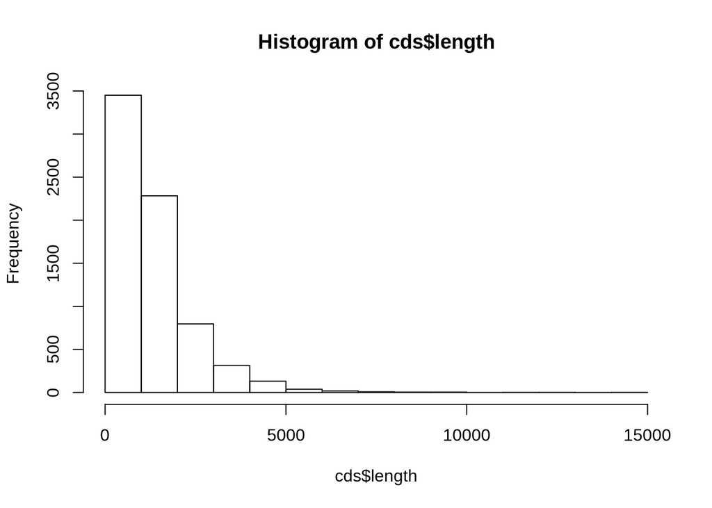

```r
hist(cds$length)
```

Choose the class intervals in a way that the histogram is informative (neither too large nor too few classes).

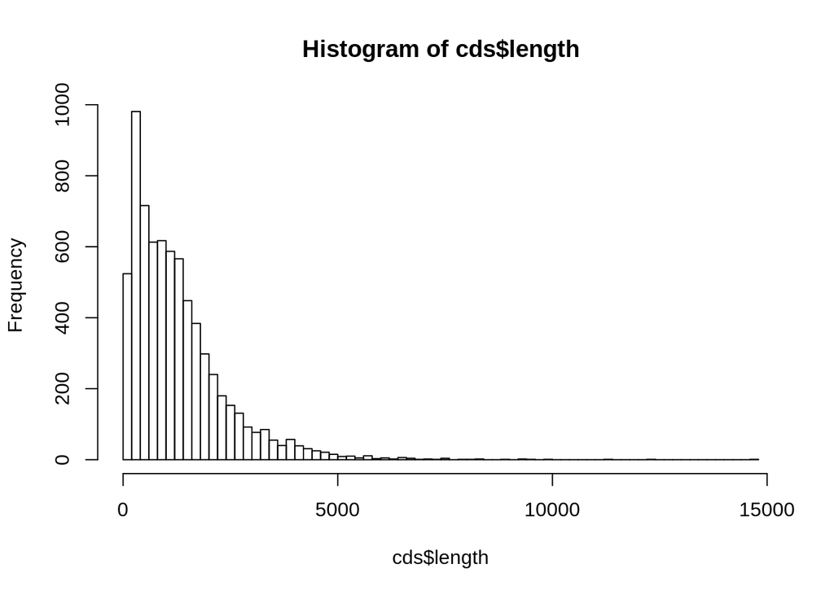

```r
## Take more or less 100 bins
h <- hist(cds$length, breaks=100)
```

Retrieve the result of `hist()` in a variable named `cds.length.hist`.

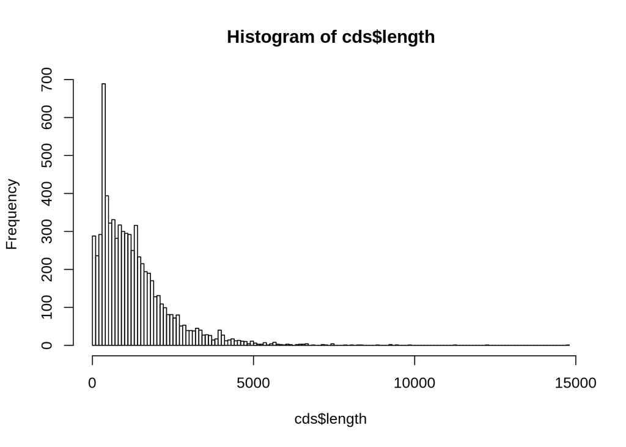

```r
## Define breaks exactly in the way you wish
cds.length.hist <- hist(cds$length, breaks=seq(from=0, to=max(cds$length)+100, by=100))
```

Print the result on the screen (`print()`) and analyze the structure of the variable `cds.length.hist` (this is a list variable).

Useful functions:

```r
## Display the values used to draw the histogram
print(cds.length.hist )
```

```
$breaks
  [1]     0   100   200   300   400   500   600   700   800   900  1000
 [12]  1100  1200  1300  1400  1500  1600  1700  1800  1900  2000  2100
 [23]  2200  2300  2400  2500  2600  2700  2800  2900  3000  3100  3200
 [34]  3300  3400  3500  3600  3700  3800  3900  4000  4100  4200  4300
 [45]  4400  4500  4600  4700  4800  4900  5000  5100  5200  5300  5400
 [56]  5500  5600  5700  5800  5900  6000  6100  6200  6300  6400  6500
 [67]  6600  6700  6800  6900  7000  7100  7200  7300  7400  7500  7600
 [78]  7700  7800  7900  8000  8100  8200  8300  8400  8500  8600  8700
 [89]  8800  8900  9000  9100  9200  9300  9400  9500  9600  9700  9800
[100]  9900 10000 10100 10200 10300 10400 10500 10600 10700 10800 10900
[111] 11000 11100 11200 11300 11400 11500 11600 11700 11800 11900 12000
[122] 12100 12200 12300 12400 12500 12600 12700 12800 12900 13000 13100
[133] 13200 13300 13400 13500 13600 13700 13800 13900 14000 14100 14200
[144] 14300 14400 14500 14600 14700 14800
```

[output cut: 68 more lines]

- `class(cds.length.hist)`
- `attributes(cds.length.hist)`

Other types of graphs allow you to explore the distribution of a set of data. In particular, box plots display, for a series of data, the median, the interquartile range, a confidence interval and outliers.

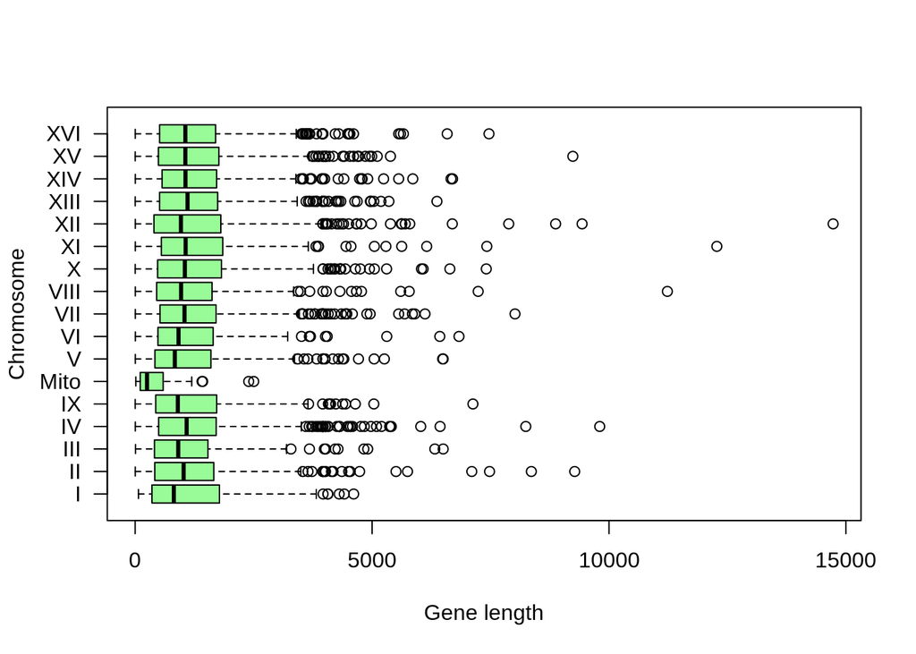

Boîte à moustache indiquant la distribution de longueur des gènes par chromosome.

```r
boxplot(length ~ seqname, data = cds, col="palegreen", horizontal=TRUE, las=1, xlab="Gene length", ylab="Chromosome")
```

### 7. Descriptive parameters

Calculate the parameters of central tendency (mean, median, mode) and dispersion (variance, standard deviation, inter-quartile deviation)

- for the genes of chromosome III;
- for all yeast genes.

```r
x <- subset(cds, seqname == "III", select = "length")
dim(x)
```

```
[1] 194   1
```

```r
class(x) ## Ah ah, this is not a vector but a data.frame
```

```
[1] "data.frame"
```

```r
## Convert the data frame into a vector
x <- unlist(x)
class(x)
```

```
[1] "numeric"
```

```r
head(x)
```

```
length1 length2 length3 length4 length5 length6
    741    1845    1374     780     630     525
```

```r
## Compute the mean, either manually or with the ad hoc R function
n <- length(x)
print(paste("Chromosome III contains", n, "CDS"))
```

```
[1] "Chromosome III contains 194 CDS"
```

```r
message("Chromosome III contains ", n, " CDS")

m <- mean(x)
print(m)
```

```
[1] 1169.521
```

```r
message("mean(x) = ", round(m, digits = 1))

## Compute the mean manually to compare the result
m.recalc <- sum(x)/n
message("Manually computed sample mean: ", round(digits=1, m.recalc))

## Compute manually standard dev of the sample
sample.var <- sum((x - m)^2)/ n
sample.sd <- sqrt(sample.var)
message("Sample standard dev =", round(digits=1, sample.sd))

## Compute an estimate of the population standard deviation
pop.sd.est <- sqrt(sum((x - m)^2) / (n-1))
message("Sample-based estimate of population standard dev =", round(digits=1, pop.sd.est))

## Compute the standard deviation with R function sd()
R.sd <- sd(x)
message("Result of R sd() function =", round(digits=1, R.sd))
```

**Ah ah! (skeptical tone)** The R function `sd()` does **not** compute the standard deviation of the input numbers ($s$), but the **estimate of the standard deviaiton of the population** ($\hat{\sigma}$)

Display these parameters on the histogram of gene length, using the function `arrows()`

### 8. Intervalle de confiance

From genes of chromosome III (considered as the sample available in 1992), calculate a confidence interval around the mean, and formulate the interpretation of this confidence interval. Then evaluate whether or not this confidence interval covered the average population (all genes in the yeast genome, which became available 4 years after chromosome III).

$$\bar{x} \pm \frac{\hat{\sigma}}{\sqrt(n)} \cdot t_{1-\alpha/2}^{n-1}$$

```r
## Define alpha, the risk
alpha <- 0.05

## Let us get the critical value for the t distribution
help("TDist")

## Which value corresponds to alpha/2

## Beware ! by default the qt() function return the lower tail
qt(p = alpha/2, df =  n - 1)
```

```
[1] -1.972332
```

```r
## For confidence intervals we need a positive t value, we thus take the upper tail
t.value <- qt(p = alpha/2, df =  n - 1, lower.tail = FALSE)

IC.min <- m - pop.sd.est * t.value /sqrt(n)
IC.max <- m + pop.sd.est * t.value /sqrt(n)

message("Confidence interval: [",
        round(digits=1, IC.min),
        ", ",
        round(digits=1, IC.max), "]")
```

Draw a polygnone of frequencies indicating the number of genes per class (class medium).

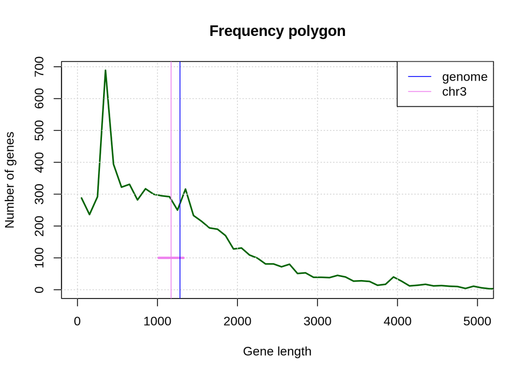

```r
## Draw a frequency polygon
plot(cds.length.hist $mids, cds.length.hist $counts,
     main="Frequency polygon",
     xlab="Gene length", ylab="Number of genes",
     type="l", col="darkgreen", lwd=2, xlim=c(0, 5000))
grid()

arrows(x0 = IC.min, y0 = 100, x1 = IC.max, y1=100, length = 0, angle = 00, col="violet", lwd=3)
abline(v = m, col="violet")

pop.mean <- mean(cds$length)
abline(v = pop.mean, col="blue")

legend("topright", legend = c("genome", "chr3"), col = c("blue", "violet"), lwd=1)
```

### 9. Distribution of gene length

- From the result of `hist()`, retrieve an array (in a variable of type `data.frame`) indicating the absolute frequencies (`count`) according to the median class size (`mids`),
- Add to this table a column indicating the relative frequency of each class of gene length.
- Add columns to this table indicating the **empirical distribution function** gene lengths (number of genes of a size less than or equal to each observed $x$ value, and relative frequency of this number).
  - basic function: `cumsum()`
  - advanced function:`ecdf()`
- by using the functions `plot()` and `lines()`, draw a graph representing the absolute frequency per class (medians of classes in $X$, counts in $Y$), and the empirical distribution function.
  - suggestion: superposez les ??utilisez le type de lignes “h” pour les fréquences de classe, et “l” ou “s” pour la fonction de répartition.

### 10. Randomly expected distribution for gene length

Based on the genome size (12.156.679 bp) and codon genomic frequencies defined below, calculate the random expected gene length distribution, and add it to the graph.

You can download the genomic frequencies of all trinucleotides here: 3nt_genomic_Saccharomyces_cerevisiae-ovlp-1str.tab

Alternative: create a variable `freq.3nt` and manually assign the values for the 4? required nucleotides from the table below.

| sequence | frequency | occurrences |
| --- | --- | --- |
| AAA | 0.0394 | 478708 |
| ATG | 0.0183 | 221902 |
| TAA | 0.0224 | 272041 |
| TAG | 0.0129 | 156668 |
| TGA | 0.0201 | 244627 |

### 11. Before finishing : keep track of your session

Traceability is an essential issue in science. The function *R* `sessionInfo()` provides a summary of the conditions of a work session: version of R, operator system, libraries of functions used.

[session information not shown]